# Knapsack Problem Results

## Group Members

Andreas, Andrew, Jaden

## Problem Description

The knapsack problem is a classic optimization problem where you have a knapsack with a limited weight capacity, and a set of items, each with a weight and a value. The goal is to select the items to put in the knapsack to maximize the total value without exceeding the weight limit.

## Knobs to Twiddle

In this experiment, we focused on adjusting the maximum number of generations to determine when we would start to experience diminishing returns in our scores.

## Unchanging System Parts

We kept the following aspects of the system constant:

- Scoring system: We used the cliff-scorer system provided in knapsack-ga.
- Mutation rate: We used the default mutation rate provided in knapsack-ga.

## Framework

We used the knapsack-ga framework for our experiment.

## Experimental Design

### Values for Knobs

We used the following sets of values for the maximum number of generations:

- 100 to 1000 with an increment interval of 100
- 10 to 250 with an increment interval of 20
- 5 to 100 with an increment interval of 5

### Number of Runs

We performed 50 runs for each set of parameter values.

### Data Collection

For each run, we collected the following data:

- Run number
- Generation count
- Generation found
- Best score
- Run time
- Incremental

## Results

### Summary

Our results suggest that increasing the maximum number of generations initially leads to improved scores, but beyond a certain point, the gains become statistically insignificant.

### Tables and Graphs

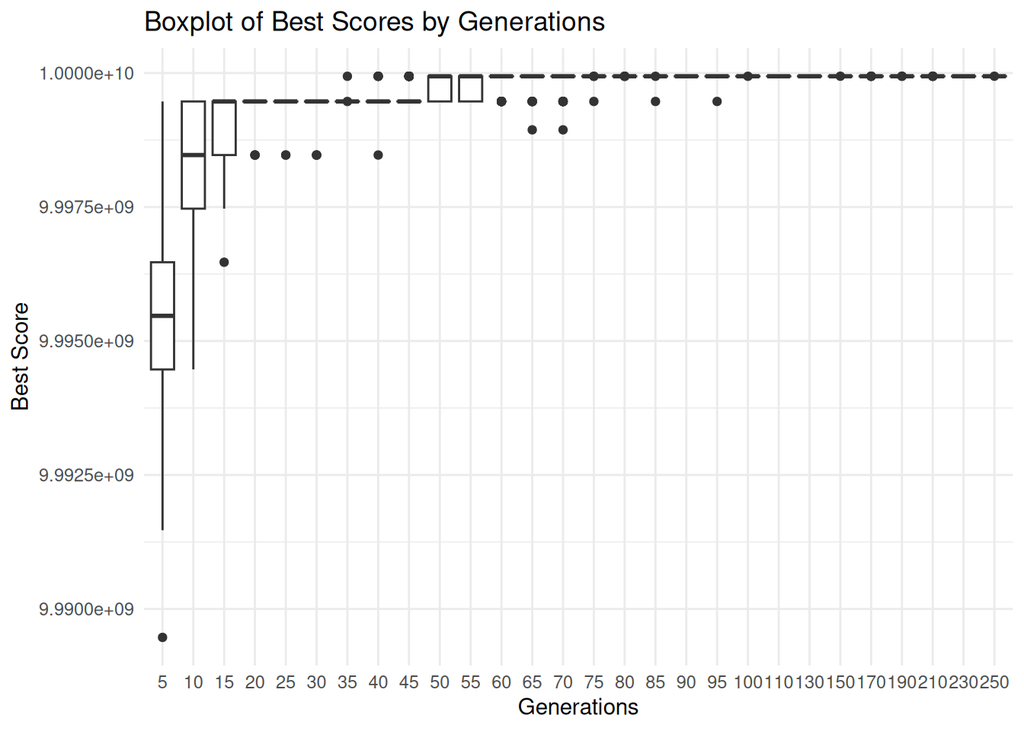

```r
library(ggplot2)
library(reshape2)

data <- read.csv("knapsack_results_250base_inc20.csv")
filtered_data <- subset(data,!(generations %in% c(5,10,15,20,25,30,35,40,45)))

# boxplot
ggplot(data, aes(x = as.factor(generations), y = best_score)) +
  geom_boxplot() +
  labs(title = "Boxplot of Best Scores by Generations",
       x = "Generations",
       y = "Best Score") +
  theme_minimal()
```

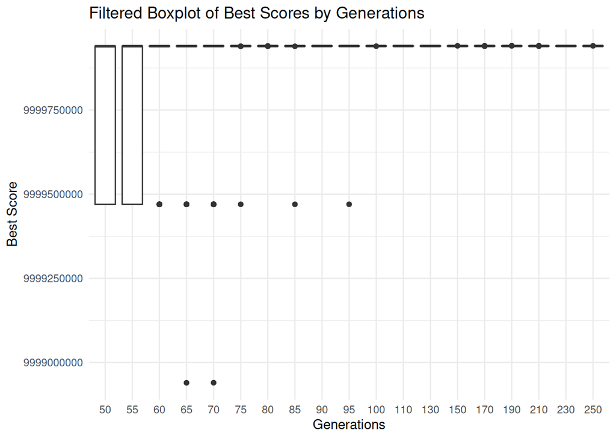

```r
ggplot(filtered_data, aes(x = as.factor(generations), y = best_score)) +
  geom_boxplot() +
  labs(title = "Filtered Boxplot of Best Scores by Generations",
       x = "Generations",
       y = "Best Score") +
  theme_minimal()
```

### Statistical Tests

We used the Pairwise Wilcoxon test to determine the point at which the number of max generations stops returning scores with a statistically significant difference.

```r
# p values

wilcox_results <- pairwise.wilcox.test(data$best_score,
                                        as.factor(data$generations),
                                        p.adjust.method = "bonferroni")

library(knitr)
library(kableExtra)

# Extract Wilcoxon test results as a matrix
matrix_results <- wilcox_results$p.value

# Replace NA values with "-" for better readability
matrix_results[is.na(matrix_results)] <- "-"

# Format as a lower triangular table
kable(matrix_results, format = "html", escape = FALSE) %>%
  kable_styling(full_width = FALSE, font_size = 10) %>%
  scroll_box(width = "100%", height = "400px")
```

5

10

15

20

25

30

35

40

45

50

55

60

65

70

75

80

85

90

95

100

110

130

150

170

190

210

230

10

7.78956528255321e-13

15

1.74816646328732e-13

5.25545880319078e-05

20

4.8622328310296e-15

2.87002796767566e-12

1

25

3.39488188791717e-15

5.21230695735759e-14

0.186097936498803

1

30

1.08586881319702e-20

2.90848388271376e-25

1.45566225690575e-06

0.742072649920114

1

35

2.66856656389055e-15

3.54874670331082e-17

5.86623506648932e-05

1

1

1

40

3.01085660257016e-15

8.52019368086245e-17

0.00012284327825247

1

1

1

1

45

3.01153361696095e-15

2.93287752012139e-18

7.99763045671153e-08

0.0029474660951029

0.0303805513759649

1

1

1

50

8.20819386548444e-21

5.21783229097149e-30

1.61642544535607e-15

1.5605115108866e-11

7.18465669980674e-11

3.17256926246529e-12

7.47294387151244e-09

9.0150388627116e-06

0.0613468894234327

55

2.66977061952264e-15

5.10929937089616e-20

1.38524089834644e-12

3.22227729135416e-10

1.86178447165694e-09

1.35969365745843e-10

2.94784559532222e-08

2.48854526343276e-06

0.00121389134763418

1

60

2.66916852740298e-15

1.0357662455831e-19

3.91061879328463e-12

2.0473248905042e-10

7.51864182928931e-10

8.82597320473428e-12

7.29482935226532e-09

3.89725732798374e-07

4.34401419620078e-05

0.402052720524453

1

65

3.01017973230625e-15

1.59110623370094e-19

1.67863394623409e-12

3.65362042632296e-11

4.86338437811686e-11

4.71290125814377e-14

4.57501142885267e-10

2.10251322858034e-09

3.89770423632453e-07

0.000814780715060428

1

1

70

9.63666566258464e-21

1.84121718630051e-30

1.60048300415676e-18

1.46533997745871e-17

1.82967075895421e-17

4.53264355382292e-26

6.48929306776996e-17

5.41858106818633e-16

7.27805241700443e-14

3.5693676703476e-13

0.000219659086746933

0.0215707036760811

1

75

2.66916852740298e-15

9.25491513980726e-21

3.82716991778288e-15

7.37416053290494e-15

9.34507676360893e-15

7.86852522376532e-20

1.29225032965461e-14

4.54020694447927e-14

2.09097670541999e-12

2.827317333886e-11

4.10382587515507e-05

0.00547781750126739

0.956859678453528

1

80

2.66916852740298e-15

8.20599906401791e-21

2.66977061952264e-15

2.66977061952264e-15

2.66916852740298e-15

8.202342313906e-21

2.83334070018717e-15

5.4758527669028e-15

7.85395810013955e-14

5.2119858302961e-14

1.11767003047391e-07

2.26963275279312e-05

0.0187804026207844

1

1

85

2.66856656389055e-15

9.25409212521148e-21

3.8263149704012e-15

7.82328616360912e-15

9.34303856883614e-15

8.18461691423451e-20

1.18287850752438e-14

2.85184859051536e-14

5.54628134722887e-13

6.4750584675899e-12

1.34328993530294e-05

0.00169213669993822

0.676743732565121

1

1

1

90

8.20307353871928e-21

9.67672310277723e-32

8.20380482613174e-21

8.20380482613174e-21

8.20307353871928e-21

9.67399794207929e-32

8.53728648857327e-21

1.75307002458861e-20

2.79286691195196e-19

3.00405775072483e-23

1.73591284916908e-11

3.31414005034854e-09

1.84144515129519e-05

0.0952469104894817

1

1

1

95

2.66916852740298e-15

8.20599906401791e-21

3.39488188791717e-15

4.06325157212057e-15

5.4758527669028e-15

3.24311190412247e-20

5.8094324405679e-15

1.49808411750166e-14

8.31832114631154e-14

4.58856675956041e-15

2.04037298787437e-08

3.42204901846457e-07

0.000706250785009234

0.689077557637363

1

1

1

1

100

8.20526758877608e-21

9.678358557885e-32

8.20599906401791e-21

8.20599906401791e-21

8.20526758877608e-21

9.67563294883387e-32

8.20380482613174e-21

1.00259841430825e-20

8.51616604586737e-20

1.83922199728845e-25

7.03640981937099e-14

1.5597866251243e-11

1.25401981294175e-07

0.00105074727973133

0.31562376067216

1

0.379919405822575

1

1

110

2.66916852740298e-15

8.20599906401791e-21

2.66977061952264e-15

2.66977061952264e-15

2.66916852740298e-15

8.202342313906e-21

2.66796472895932e-15

3.01017973230625e-15

1.18390440868518e-14

1.76297594343025e-17

1.16919630274648e-10

1.29176914349958e-09

1.86361142538058e-06

0.00915400268772532

0.33675917537252

1

0.380785402189081

1

1

1

130

2.66615999539456e-15

8.202342313906e-21

2.66676144473725e-15

2.66676144473725e-15

2.66615999539456e-15

8.19868712865327e-21

2.66495748211659e-15

2.66615999539456e-15

1.18262216352835e-14

7.36895329645644e-17

2.70023899492417e-10

8.39713969653724e-09

1.21640592991978e-05

0.0251060358943068

0.660850466025387

1

1

1

1

1

1

150

2.66916852740298e-15

8.20599906401791e-21

2.66977061952264e-15

2.66977061952264e-15

2.66916852740298e-15

8.202342313906e-21

2.66796472895932e-15

3.01017973230625e-15

1.02120031186634e-14

2.3250856025226e-17

1.43376783986083e-10

1.73110097739534e-09

3.24752809945205e-06

0.00209721027590952

0.0797428325614887

1

0.26910594629939

1

1

1

1

1

170

2.66916852740298e-15

8.20599906401791e-21

2.66977061952264e-15

2.66977061952264e-15

2.66916852740298e-15

8.202342313906e-21

2.66796472895932e-15

3.60382932870289e-15

7.82500103958728e-15

9.38402202203278e-19

2.96323841465508e-11

3.28984253630315e-11

2.68926892871069e-08

4.00279983069243e-06

0.000207408749323229

0.00145755951367411

0.00246624985812695

0.311115060148792

0.340956435926154

1

1

1

1

190

2.66977061952264e-15

8.20673060187988e-21

2.67037284027534e-15

2.67037284027534e-15

2.66977061952264e-15

8.20307353871928e-21

2.66856656389055e-15

2.83525549961341e-15

9.62776119141756e-15

7.63960760467976e-18

4.86664458643224e-11

6.48079171352547e-10

1.42242629901235e-06

0.00127559351969785

0.0376401971813908

0.956916918484628

0.217041350809774

1

1

1

1

1

1

1

210

2.66977061952264e-15

8.20673060187988e-21

2.67037284027534e-15

2.67037284027534e-15

2.66977061952264e-15

8.20307353871928e-21

2.83397883054509e-15

3.39488188791717e-15

1.49872941789608e-14

1.93368565183507e-17

1.75830845197818e-10

1.23023735418726e-09

2.9923571442951e-06

0.0019075863414007

0.0686276916963645

0.70086431110547

0.255890150548949

1

1

1

1

1

1

1

1

230

2.66916852740298e-15

8.20599906401791e-21

2.66977061952264e-15

2.66977061952264e-15

2.66916852740298e-15

8.202342313906e-21

2.66796472895932e-15

3.39412109887116e-15

1.41280428575637e-14

8.8403633427227e-17

4.2454376924864e-10

1.1664524722135e-08

1.48143755666498e-05

0.00534670971461978

0.228374844944337

1

0.503206744916674

1

1

1

1

1

1

1

1

1

250

2.67037284027534e-15

8.20746220236697e-21

2.67097518968703e-15

2.67097518968703e-15

2.67037284027534e-15

8.20380482613174e-21

2.66916852740298e-15

2.67037284027534e-15

6.55087205281513e-15

1.42761901897377e-18

6.53206553635698e-12

5.68363413393438e-11

3.087697172095e-08

1.07020564577298e-05

0.00102631143473862

0.0112993983627825

0.00238705271012729

0.762288304243398

1

1

1

1

1

1

1

1

1

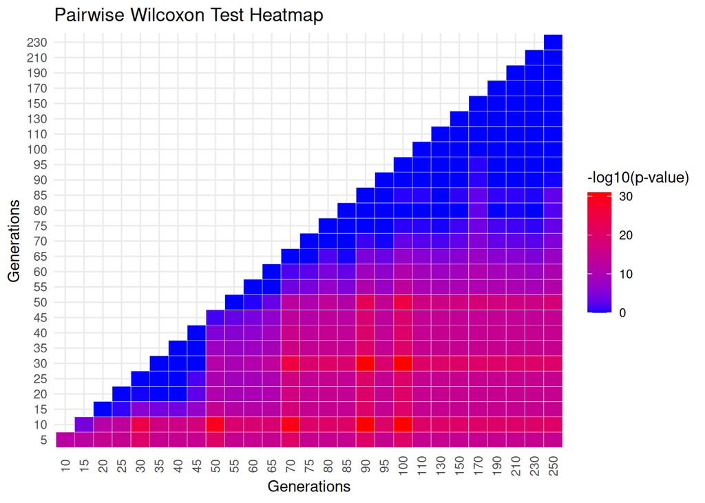

```r
# Convert Wilcoxon test results into a data frame
wilcox_matrix <- as.data.frame(as.table(wilcox_results$p.value))

# Rename columns for clarity
colnames(wilcox_matrix) <- c("Gen1", "Gen2", "P_Value")

# Remove NA values
wilcox_matrix <- na.omit(wilcox_matrix)

# Convert generations to numeric
wilcox_matrix$Gen1 <- as.numeric(as.character(wilcox_matrix$Gen1))
wilcox_matrix$Gen2 <- as.numeric(as.character(wilcox_matrix$Gen2))

# Create the heatmap
ggplot(wilcox_matrix, aes(x = factor(Gen1, levels = unique(wilcox_matrix$Gen1)),
                           y = factor(Gen2, levels = unique(wilcox_matrix$Gen2)),
                           fill = -log10(P_Value))) +
  geom_tile(color = "white") +
  scale_fill_gradient(low = "blue", high = "red", name = "-log10(p-value)") +
  labs(title = "Pairwise Wilcoxon Test Heatmap",
       x = "Generations",
       y = "Generations") +
  theme_minimal() +
  theme(axis.text.x = element_text(angle = 90, vjust = 0.5))
```